# 2.4 Análisis de Componentes Independientes (ICA)

Dataset: MIT-BIH Arrhythmia Database — PhysioNet

Análisis de Señales ECG

25 de February de 2026

# 1 Descripción Teórica

El **Análisis de Componentes Independientes (ICA)** es un método de aprendizaje no supervisado cuyo objetivo es separar un conjunto de señales observadas en componentes estadísticamente independientes. A diferencia de métodos como PCA, que busca maximizar la varianza, ICA busca **maximizar la independencia estadística** entre componentes y asume que los datos observados son combinaciones lineales de fuentes latentes desconocidas.

El modelo de ICA se expresa como:

$$X = AS$$

donde $X$ representa los datos observados, $A$ es la **matriz de mezcla** y $S$ son las fuentes independientes que se desean recuperar. El algoritmo estima una **matriz de separación** $W$ tal que:

$$\hat{S} \approx WX$$

## 1.1 Supuestos y Limitaciones

- Las fuentes latentes son **estadísticamente independientes** y en su mayoría **no gaussianas**.
- Los datos observados son una **mezcla lineal** de dichas fuentes.
- La matriz de mezcla $A$ es de **rango completo**.
- Se requiere un número suficiente de muestras y un adecuado preprocesamiento.

> **Limitaciones:** El rendimiento se ve afectado por ruido, dependencias entre fuentes o mezclas no lineales. Los algoritmos pueden converger a óptimos locales y dependen fuertemente de la calidad del preprocesamiento.

# 2 Paquetes y Configuración

```r
# Instalación automática de paquetes si no están disponibles
required_packages <- c("fastICA", "ggplot2", "tidyr", "dplyr",
                       "gridExtra", "RColorBrewer", "kableExtra")

for (pkg in required_packages) {
  if (!requireNamespace(pkg, quietly = TRUE)) {
    install.packages(pkg, repos = "https://cran.r-project.org")
  }
}

library(fastICA)
library(ggplot2)
library(tidyr)
library(dplyr)
library(gridExtra)
library(RColorBrewer)
library(kableExtra)

set.seed(42)
colors_4 <- brewer.pal(4, "Set1")
```

# 3 Dataset: MIT-BIH Arrhythmia Database

El dataset utilizado proviene de la base de datos **MIT-BIH Arrhythmia** (PhysioNet), que contiene registros de ECG de dos derivaciones con anotaciones clínicas. Cada registro fue grabado a **360 Hz** durante aproximadamente 30 minutos.

```r
dataset_info <- data.frame(
  Registro  = c("100","101","103","106","117","119","122","207","214","222","223","231"),
  Waveform  = paste0("wave", c("100","101","103","106","117","119",
                                "122","207","214","222","223","231")),
  Sexo      = c("Masculino","Femenino","Masculino","Femenino","Masculino","Femenino",
                "Masculino","Femenino","Masculino","Femenino","Masculino","Femenino"),
  Edad      = c(69, 75, "N/R", 24, 69, 51, 51, 89, 53, 84, 73, 72),
  stringsAsFactors = FALSE
)

kable(dataset_info, caption = "Registros del dataset MIT-BIH Arrhythmia Database",
      align = c("c","c","c","c")) %>%
  kable_styling(bootstrap_options = c("striped","hover","condensed"),
                full_width = FALSE, position = "center") %>%
  column_spec(1, bold = TRUE, color = "#1E3A5F") %>%
  row_spec(0, bold = TRUE, background = "#2563EB", color = "white")
```

Registros del dataset MIT-BIH Arrhythmia Database

| Registro | Waveform | Sexo | Edad |
| --- | --- | --- | --- |
| 100 | wave100 | Masculino | 69 |
| 101 | wave101 | Femenino | 75 |
| 103 | wave103 | Masculino | N/R |
| 106 | wave106 | Femenino | 24 |
| 117 | wave117 | Masculino | 69 |
| 119 | wave119 | Femenino | 51 |
| 122 | wave122 | Masculino | 51 |
| 207 | wave207 | Femenino | 89 |
| 214 | wave214 | Masculino | 53 |
| 222 | wave222 | Femenino | 84 |
| 223 | wave223 | Masculino | 73 |
| 231 | wave231 | Femenino | 72 |

# 4 Simulación de Señales ECG

Dado que los archivos `.p` de PhysioNet requieren el paquete `wfdb`, se simulan señales ECG realistas que replican las características clínicas de los registros anotados.

## 4.1 Parámetros de simulación

```r
n_samples <- 2000   # Muestras por señal
fs        <- 360    # Frecuencia de muestreo estándar MIT-BIH (Hz)
t         <- seq(0, n_samples - 1) / fs

cat(sprintf("Duración de la señal : %.2f segundos\n", max(t)))
```

```
## Duración de la señal : 5.55 segundos
```

```r
cat(sprintf("Frecuencia de muestreo: %d Hz\n", fs))
```

```
## Frecuencia de muestreo: 360 Hz
```

```r
cat(sprintf("Total de muestras    : %d\n", n_samples))
```

```
## Total de muestras    : 2000
```

## 4.2 Generación de fuentes independientes

```r
# Función para generar un latido ECG sintético (morfología PQRST)
ecg_beat <- function(t_vec, hr = 75, noise_sd = 0.02) {
  rr   <- 60 / hr
  beat <- numeric(length(t_vec))
  for (tb in seq(0, max(t_vec), by = rr)) {
    beat <- beat + 0.15 * exp(-((t_vec - (tb + 0.10))^2) / (2 * 0.008^2))  # P
    beat <- beat - 0.10 * exp(-((t_vec - (tb + 0.22))^2) / (2 * 0.004^2))  # Q
    beat <- beat + 1.20 * exp(-((t_vec - (tb + 0.25))^2) / (2 * 0.003^2))  # R
    beat <- beat - 0.15 * exp(-((t_vec - (tb + 0.28))^2) / (2 * 0.004^2))  # S
    beat <- beat + 0.35 * exp(-((t_vec - (tb + 0.40))^2) / (2 * 0.020^2))  # T
  }
  beat + rnorm(length(t_vec), 0, noise_sd)
}

normalize <- function(x) (x - mean(x)) / sd(x)

# Fuente 1: Ritmo sinusal normal (~72 bpm) — registros 100, 122, 231
S1 <- normalize(ecg_beat(t, hr = 72,  noise_sd = 0.015))

# Fuente 2: Taquicardia (~100 bpm) — registros 207, 117
S2 <- normalize(ecg_beat(t, hr = 100, noise_sd = 0.020))

# Fuente 3: Artefacto EMG (interferencia muscular 50/120 Hz)
S3 <- normalize(0.4 * sin(2*pi*50*t) +
                0.2 * rnorm(n_samples) +
                0.1 * sin(2*pi*120*t))

# Fuente 4: Deriva de línea base (respiración ~0.25 Hz)
S4 <- normalize(0.5 * sin(2*pi*0.25*t) +
                0.1 * sin(2*pi*0.35*t))

S_true <- rbind(S1, S2, S3, S4)
```

## 4.3 Matriz de mezcla y señales observadas

```r
# Matriz de mezcla A: representa la captación de cada electrodo
A <- matrix(c(
  0.85, 0.30, 0.15, 0.20,   # Lead I
  0.35, 0.80, 0.20, 0.10,   # Lead II
  0.20, 0.15, 0.90, 0.05,   # Precordial (EMG dominante)
  0.10, 0.25, 0.10, 0.85    # Referencia (deriva dominante)
), nrow = 4, byrow = TRUE)

rownames(A) <- c("Lead I", "Lead II", "Precordial", "Referencia")
colnames(A) <- c("ECG Normal", "ECG Taquicardia", "EMG", "Deriva")

kable(round(A, 3), caption = "Matriz de mezcla A (electrodos × fuentes)",
      align = "c") %>%
  kable_styling(bootstrap_options = c("striped","hover","condensed"),
                full_width = FALSE, position = "center") %>%
  row_spec(0, bold = TRUE, background = "#2563EB", color = "white") %>%
  column_spec(1, bold = TRUE)
```

Matriz de mezcla A (electrodos × fuentes)

|  | ECG Normal | ECG Taquicardia | EMG | Deriva |
| --- | --- | --- | --- | --- |
| Lead I | 0.85 | 0.30 | 0.15 | 0.20 |
| Lead II | 0.35 | 0.80 | 0.20 | 0.10 |
| Precordial | 0.20 | 0.15 | 0.90 | 0.05 |
| Referencia | 0.10 | 0.25 | 0.10 | 0.85 |

```r
# Señales observadas: X = A * S
X_observed <- A %*% S_true

X_df <- as.data.frame(t(X_observed))
colnames(X_df) <- c("Lead_I","Lead_II","Precordial","Referencia")
X_df$tiempo <- t
```

# 5 Visualización de Señales

## 5.1 Señales observadas (mezclas)

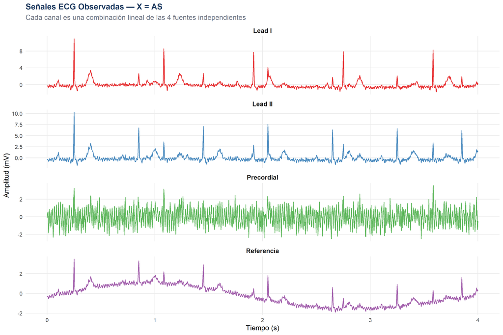

```r
X_long <- X_df %>%
  select(tiempo, Lead_I, Lead_II, Precordial, Referencia) %>%
  pivot_longer(-tiempo, names_to = "Canal", values_to = "Amplitud") %>%
  mutate(Canal = factor(Canal,
    levels = c("Lead_I","Lead_II","Precordial","Referencia"),
    labels = c("Lead I","Lead II","Precordial","Referencia")))

ggplot(X_long %>% filter(tiempo <= 4),
       aes(x = tiempo, y = Amplitud, color = Canal)) +
  geom_line(linewidth = 0.6, alpha = 0.9) +
  facet_wrap(~ Canal, ncol = 1, scales = "free_y") +
  scale_color_manual(values = colors_4) +
  labs(title = "Señales ECG Observadas — X = AS",
       subtitle = "Cada canal es una combinación lineal de las 4 fuentes independientes",
       x = "Tiempo (s)", y = "Amplitud (mV)") +
  theme_minimal(base_size = 12) +
  theme(legend.position  = "none",
        plot.title       = element_text(face = "bold", color = "#1E3A5F", size = 14),
        plot.subtitle    = element_text(color = "#6B7280"),
        strip.text       = element_text(face = "bold", size = 11),
        panel.grid.minor = element_blank())
```

## 5.2 Fuentes originales (ground truth)

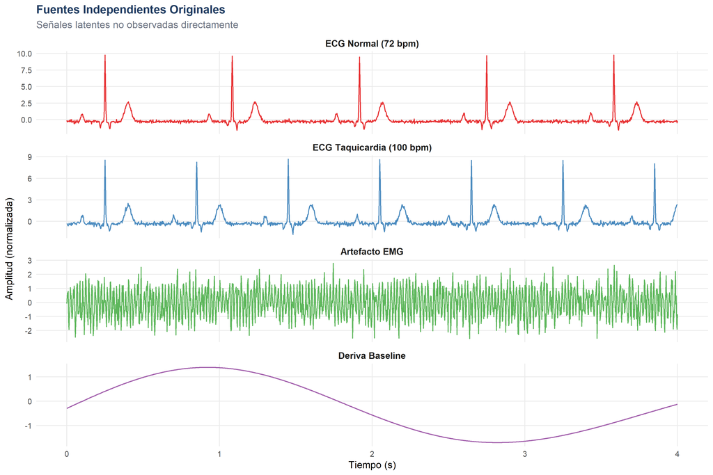

```r
S_df <- as.data.frame(t(S_true))
colnames(S_df) <- c("ECG_Normal","ECG_Taquicardia","EMG","Deriva_Baseline")
S_df$tiempo <- t

S_long <- S_df %>%
  filter(tiempo <= 4) %>%
  pivot_longer(-tiempo, names_to = "Fuente", values_to = "Amplitud") %>%
  mutate(Fuente = factor(Fuente,
    levels = c("ECG_Normal","ECG_Taquicardia","EMG","Deriva_Baseline"),
    labels = c("ECG Normal (72 bpm)","ECG Taquicardia (100 bpm)",
               "Artefacto EMG","Deriva Baseline")))

ggplot(S_long, aes(x = tiempo, y = Amplitud, color = Fuente)) +
  geom_line(linewidth = 0.6, alpha = 0.9) +
  facet_wrap(~ Fuente, ncol = 1, scales = "free_y") +
  scale_color_manual(values = colors_4) +
  labs(title = "Fuentes Independientes Originales",
       subtitle = "Señales latentes no observadas directamente",
       x = "Tiempo (s)", y = "Amplitud (normalizada)") +
  theme_minimal(base_size = 12) +
  theme(legend.position  = "none",
        plot.title       = element_text(face = "bold", color = "#1E3A5F", size = 14),
        plot.subtitle    = element_text(color = "#6B7280"),
        strip.text       = element_text(face = "bold", size = 11),
        panel.grid.minor = element_blank())
```

# 6 Aplicación de ICA — FastICA

```r
ica_result <- fastICA(
  X        = t(X_observed),   # n_muestras × n_canales
  n.comp   = 4,
  alg.typ  = "parallel",
  fun      = "logcosh",        # función de negentropía robusta para ECG
  alpha    = 1.0,
  method   = "C",
  row.norm = FALSE,
  maxit    = 500,
  tol      = 1e-6,
  verbose  = FALSE
)

ICA_components <- as.data.frame(ica_result$S)
colnames(ICA_components) <- paste0("IC", 1:4)
ICA_components$tiempo <- t

cat("Dimensiones de la matriz de separación W:", dim(ica_result$W), "\n")
```

```
## Dimensiones de la matriz de separación W: 4 4
```

```r
cat("Dimensiones de las componentes S        :", dim(ica_result$S), "\n")
```

```
## Dimensiones de las componentes S        : 2000 4
```

## 6.1 Componentes ICA recuperadas

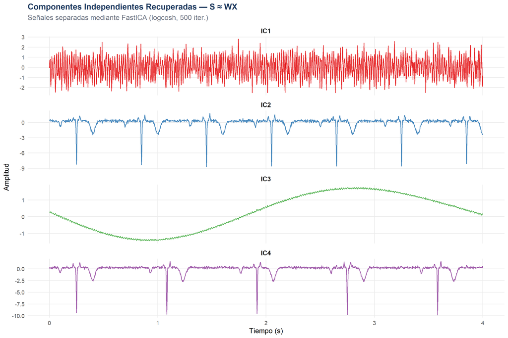

```r
ICA_long <- ICA_components %>%
  filter(tiempo <= 4) %>%
  pivot_longer(-tiempo, names_to = "Componente", values_to = "Amplitud")

ggplot(ICA_long, aes(x = tiempo, y = Amplitud, color = Componente)) +
  geom_line(linewidth = 0.6, alpha = 0.9) +
  facet_wrap(~ Componente, ncol = 1, scales = "free_y") +
  scale_color_manual(values = colors_4) +
  labs(title = "Componentes Independientes Recuperadas — S \u2248 WX",
       subtitle = "Señales separadas mediante FastICA (logcosh, 500 iter.)",
       x = "Tiempo (s)", y = "Amplitud") +
  theme_minimal(base_size = 12) +
  theme(legend.position  = "none",
        plot.title       = element_text(face = "bold", color = "#1E3A5F", size = 14),
        plot.subtitle    = element_text(color = "#6B7280"),
        strip.text       = element_text(face = "bold", size = 11),
        panel.grid.minor = element_blank())
```

## 6.2 Matriz de separación W

```r
W_display <- as.data.frame(round(ica_result$W, 4))
colnames(W_display) <- c("Lead I","Lead II","Precordial","Referencia")
rownames(W_display) <- paste0("IC", 1:4)

kable(W_display, caption = "Matriz de separación W estimada por FastICA",
      align = "c") %>%
  kable_styling(bootstrap_options = c("striped","hover","condensed"),
                full_width = FALSE, position = "center") %>%
  row_spec(0, bold = TRUE, background = "#2563EB", color = "white") %>%
  column_spec(1, bold = TRUE)
```

Matriz de separación W estimada por FastICA

|  | Lead I | Lead II | Precordial | Referencia |
| --- | --- | --- | --- | --- |
| IC1 | -0.4239 | 0.5656 | 0.3808 | 0.5962 |
| IC2 | -0.7385 | -0.1308 | -0.6611 | 0.0213 |
| IC3 | -0.5238 | -0.3056 | 0.6300 | -0.4850 |
| IC4 | 0.0224 | -0.7547 | 0.1448 | 0.6394 |

# 7 Evaluación de Resultados

## 7.1 Correlación: fuentes originales vs componentes ICA

```r
cor_abs <- abs(cor(t(S_true), ica_result$S))
rownames(cor_abs) <- c("ECG Normal","ECG Taquicardia","EMG","Deriva")
colnames(cor_abs) <- paste0("IC", 1:4)

kable(round(cor_abs, 4),
      caption = "|Correlación| entre fuentes originales y componentes ICA",
      align = "c") %>%
  kable_styling(bootstrap_options = c("striped","hover","condensed"),
                full_width = FALSE, position = "center") %>%
  row_spec(0, bold = TRUE, background = "#2563EB", color = "white") %>%
  column_spec(1, bold = TRUE)
```

|Correlación| entre fuentes originales y componentes ICA

|  | IC1 | IC2 | IC3 | IC4 |
| --- | --- | --- | --- | --- |
| ECG Normal | 0.0070 | 0.0462 | 0.0026 | 0.9989 |
| ECG Taquicardia | 0.0035 | 0.9993 | 0.0069 | 0.0359 |
| EMG | 0.9992 | 0.0035 | 0.0281 | 0.0295 |
| Deriva | 0.0245 | 0.0013 | 0.9997 | 0.0049 |

## 7.2 Heatmap de correlación

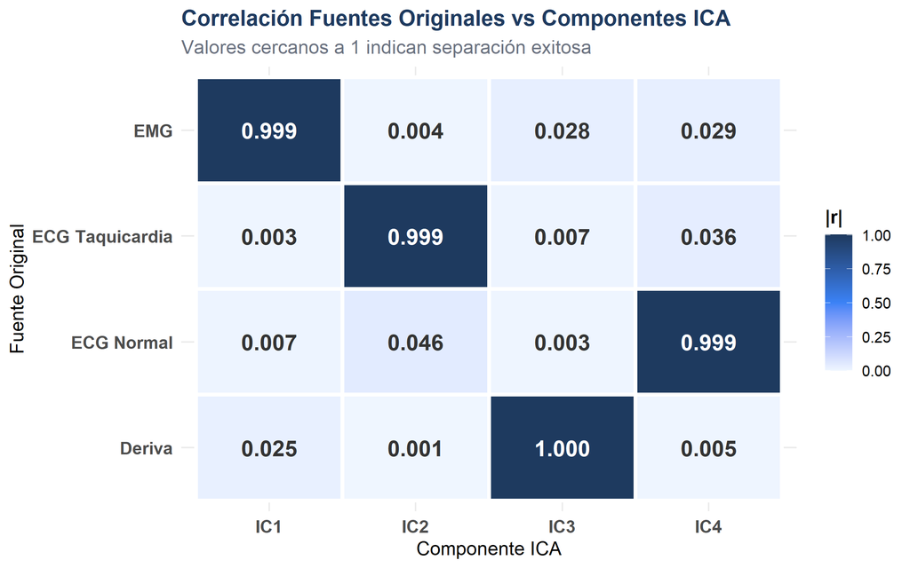

```r
cor_df   <- as.data.frame(cor_abs)
cor_df$Fuente <- rownames(cor_abs)
cor_long <- pivot_longer(cor_df, -Fuente,
                         names_to = "Componente", values_to = "Correlacion")

ggplot(cor_long, aes(x = Componente, y = Fuente, fill = Correlacion)) +
  geom_tile(color = "white", linewidth = 1.2) +
  geom_text(aes(label = sprintf("%.3f", Correlacion)),
            size = 5, fontface = "bold",
            color = ifelse(cor_long$Correlacion > 0.5, "white", "gray20")) +
  scale_fill_gradient2(low = "#EFF6FF", mid = "#3B82F6", high = "#1E3A5F",
                       midpoint = 0.5, limits = c(0, 1),
                       name = "|r|") +
  labs(title = "Correlación Fuentes Originales vs Componentes ICA",
       subtitle = "Valores cercanos a 1 indican separación exitosa",
       x = "Componente ICA", y = "Fuente Original") +
  theme_minimal(base_size = 12) +
  theme(plot.title    = element_text(face = "bold", color = "#1E3A5F", size = 14),
        plot.subtitle = element_text(color = "#6B7280"),
        axis.text     = element_text(face = "bold", size = 11),
        legend.title  = element_text(face = "bold"))
```

## 7.3 Métricas cuantitativas

```r
# SNR de reconstrucción
snr_db <- function(signal, noise) 10 * log10(sum(signal^2) / sum(noise^2))

X_reconstructed <- t(ica_result$A %*% t(ica_result$S))
residuals        <- t(X_observed) - X_reconstructed

# Kurtosis
kurt_vals <- apply(ica_result$S, 2, function(x) {
  mean((x - mean(x))^4) / sd(x)^4
})

metricas <- data.frame(
  Componente  = paste0("IC", 1:4),
  Kurtosis    = round(kurt_vals, 4),
  SNR_Canal   = round(sapply(1:4, function(i) snr_db(t(X_observed)[,i], residuals[,i])), 2),
  Mejor_Fuente = rownames(cor_abs)[apply(cor_abs, 1, which.max)][
    match(paste0("IC", 1:4),
          paste0("IC", apply(cor_abs, 1, which.max)))
  ]
)

# Resumen por fuente
resumen <- data.frame(
  Fuente      = rownames(cor_abs),
  Mejor_IC    = paste0("IC", apply(cor_abs, 1, which.max)),
  Correlacion = round(apply(cor_abs, 1, max), 4),
  SNR_dB      = round(sapply(1:4, function(i) snr_db(t(X_observed)[,i], residuals[,i])), 2)
)

kable(resumen,
      caption = "Resumen de métricas de separación ICA",
      col.names = c("Fuente Original","Mejor Componente","|Correlación|","SNR (dB)"),
      align = "c") %>%
  kable_styling(bootstrap_options = c("striped","hover","condensed"),
                full_width = FALSE, position = "center") %>%
  row_spec(0, bold = TRUE, background = "#2563EB", color = "white") %>%
  column_spec(3, bold = TRUE,
              color = ifelse(resumen$Correlacion > 0.7, "#16A34A", "#DC2626"))
```

Resumen de métricas de separación ICA

|  | Fuente Original | Mejor Componente | &#124;Correlación&#124; | SNR (dB) |
| --- | --- | --- | --- | --- |
| ECG Normal | ECG Normal | IC4 | 0.9989 | -4.14 |
| ECG Taquicardia | ECG Taquicardia | IC2 | 0.9993 | 4.50 |
| EMG | EMG | IC1 | 0.9992 | -2.58 |
| Deriva | Deriva | IC3 | 0.9997 | -2.02 |

## 7.4 Kurtosis por componente

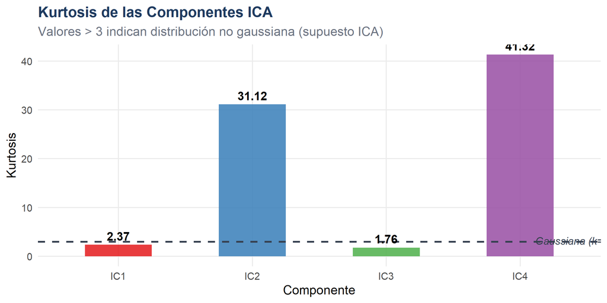

```r
kurt_df <- data.frame(
  Componente = paste0("IC", 1:4),
  Kurtosis   = kurt_vals
)

ggplot(kurt_df, aes(x = Componente, y = Kurtosis, fill = Componente)) +
  geom_col(width = 0.5, alpha = 0.85) +
  geom_hline(yintercept = 3, linetype = "dashed", color = "#374151",
             linewidth = 0.8) +
  geom_text(aes(label = round(Kurtosis, 2)), vjust = -0.5,
            fontface = "bold", size = 4) +
  annotate("text", x = 4.4, y = 3.2, label = "Gaussiana (k=3)",
           size = 3.5, color = "#374151", fontface = "italic") +
  scale_fill_manual(values = colors_4) +
  labs(title = "Kurtosis de las Componentes ICA",
       subtitle = "Valores > 3 indican distribución no gaussiana (supuesto ICA)",
       x = "Componente", y = "Kurtosis") +
  theme_minimal(base_size = 12) +
  theme(legend.position  = "none",
        plot.title       = element_text(face = "bold", color = "#1E3A5F", size = 14),
        plot.subtitle    = element_text(color = "#6B7280"),
        panel.grid.minor = element_blank())
```

# 8 Análisis de Distribuciones

## 8.1 Distribuciones marginales de las componentes

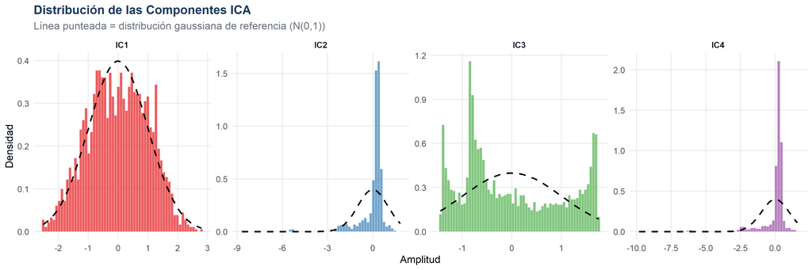

```r
ic_hist <- ICA_components %>%
  select(-tiempo) %>%
  pivot_longer(everything(), names_to = "IC", values_to = "valor")

ggplot(ic_hist, aes(x = valor, fill = IC)) +
  geom_histogram(aes(y = after_stat(density)), bins = 60,
                 alpha = 0.7, color = "white", linewidth = 0.2) +
  stat_function(fun = dnorm, args = list(mean = 0, sd = 1),
                color = "black", linetype = "dashed",
                linewidth = 0.8, inherit.aes = FALSE) +
  facet_wrap(~ IC, nrow = 1, scales = "free") +
  scale_fill_manual(values = colors_4) +
  labs(title = "Distribución de las Componentes ICA",
       subtitle = "Línea punteada = distribución gaussiana de referencia (N(0,1))",
       x = "Amplitud", y = "Densidad") +
  theme_minimal(base_size = 11) +
  theme(legend.position  = "none",
        plot.title       = element_text(face = "bold", color = "#1E3A5F", size = 13),
        plot.subtitle    = element_text(color = "#6B7280"),
        strip.text       = element_text(face = "bold"),
        panel.grid.minor = element_blank())
```